# Assignment 3 - Part 2: Question 3 and Question 4

Yunjia Zeng (Collaborated with Mengtong Zhang and Shaoyu Feng)

4/1/2020

```r
library(rpart)
library(tidyverse)
library(splines)
library(Rtsne)
library(RColorBrewer)
#install.packages("devtools")
#devtools::install_github("bmschmidt/wordVectors")
library(wordVectors)
library(tidytext)
```

### Question 3

```r
####################################
#####       Download data      #####
####################################
# -- Check to see  if file exists --
if (!file.exists("cookbooks.zip")) {
  download.file("http://archive.lib.msu.edu/dinfo/feedingamerica/cookbook_text.zip","cookbooks.zip")
}
unzip("cookbooks.zip",exdir="cookbooks")
if (!file.exists("cookbooks.txt")) prep_word2vec(origin="cookbooks",destination="cookbooks.txt",lowercase=T,bundle_ngrams=1)

# Training a Word2Vec model
if (!file.exists("cookbook_vectors.bin")) {
  model = train_word2vec("cookbooks.txt","cookbook_vectors.bin",
                         vectors=100,threads=4,window=6,
                         min_count = 10,
                         iter=5,negative_samples=15)
} else{
    model = read.vectors("cookbook_vectors.bin")
    }
```

```
## Filename ends with .bin, so reading in binary format
```

```
## Reading a word2vec binary file of 18952 rows and 100 columns
```

#### 1

We can do stop words removal, stemming or lemmatization and text normalization to improve the quality of embedding.

#### 2

Ingredients: Venison, Milk, and Mutton

```r
####################################
#####      Proximity search    #####
####################################
ingredient = 'venison'
ingredient_2 = 'milk'
ingredient_3 = 'mutton'
list_of_ingredients = c(ingredient, ingredient_2, ingredient_3)
model %>% closest_to(model[[list_of_ingredients]],5)
```

```
##      word similarity to model[[list_of_ingredients]]
## 1  mutton                                  0.8918762
## 2 venison                                  0.8718282
## 3    lamb                                  0.7851596
## 4    veal                                  0.7730906
## 5    loin                                  0.7411460
```

and the five closest words are: Mutton, Venison, Lamb, Veal, and Loin.

#### 3

Now we use tSNE find out the relationships between set of words that related to the three ingredients in previous question.

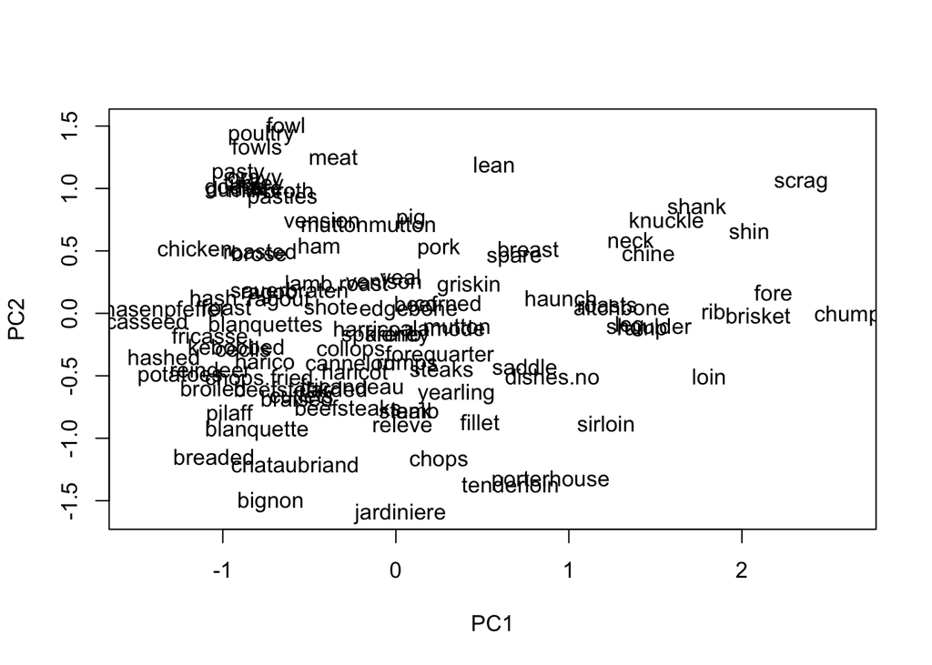

```r
#############################################
#####   Using TSNE to see similarity    #####
#############################################
# We have a list of potential herb-related words from old cookbooks.
n_words = 100
closest_ingredients = closest_to(model,model[[list_of_ingredients]], n_words)$word
surrounding_ingredients = model[[closest_ingredients,average=F]]
plot(surrounding_ingredients,method="pca")
```

```r
embedding = Rtsne(X = surrounding_ingredients, dims = 2,
                  perplexity = 4,
                  theta = 0.5,
                  eta = 10,
                  pca = TRUE, verbose = TRUE,
                  max_iter = 2000)
```

```
## Performing PCA
## Read the 100 x 50 data matrix successfully!
## OpenMP is working. 1 threads.
## Using no_dims = 2, perplexity = 4.000000, and theta = 0.500000
## Computing input similarities...
## Building tree...
## Done in 0.00 seconds (sparsity = 0.180800)!
## Learning embedding...
## Iteration 50: error is 64.028712 (50 iterations in 0.01 seconds)
## Iteration 100: error is 64.028709 (50 iterations in 0.01 seconds)
## Iteration 150: error is 64.028536 (50 iterations in 0.01 seconds)
## Iteration 200: error is 64.016793 (50 iterations in 0.01 seconds)
## Iteration 250: error is 63.746363 (50 iterations in 0.01 seconds)
## Iteration 300: error is 1.133922 (50 iterations in 0.01 seconds)
## Iteration 350: error is 1.010967 (50 iterations in 0.01 seconds)
## Iteration 400: error is 0.974086 (50 iterations in 0.01 seconds)
## Iteration 450: error is 0.960293 (50 iterations in 0.01 seconds)
## Iteration 500: error is 0.953791 (50 iterations in 0.01 seconds)
## Iteration 550: error is 0.952337 (50 iterations in 0.01 seconds)
## Iteration 600: error is 0.948733 (50 iterations in 0.01 seconds)
## Iteration 650: error is 0.945804 (50 iterations in 0.01 seconds)
## Iteration 700: error is 0.939912 (50 iterations in 0.01 seconds)
## Iteration 750: error is 0.937347 (50 iterations in 0.01 seconds)
## Iteration 800: error is 0.937577 (50 iterations in 0.01 seconds)
## Iteration 850: error is 0.935777 (50 iterations in 0.01 seconds)
## Iteration 900: error is 0.932398 (50 iterations in 0.01 seconds)
## Iteration 950: error is 0.931773 (50 iterations in 0.01 seconds)
## Iteration 1000: error is 0.930050 (50 iterations in 0.01 seconds)
## Iteration 1050: error is 0.928535 (50 iterations in 0.01 seconds)
## Iteration 1100: error is 0.926779 (50 iterations in 0.01 seconds)
## Iteration 1150: error is 0.925347 (50 iterations in 0.01 seconds)
## Iteration 1200: error is 0.924089 (50 iterations in 0.01 seconds)
## Iteration 1250: error is 0.922959 (50 iterations in 0.01 seconds)
## Iteration 1300: error is 0.924247 (50 iterations in 0.01 seconds)
## Iteration 1350: error is 0.923545 (50 iterations in 0.01 seconds)
## Iteration 1400: error is 0.922589 (50 iterations in 0.01 seconds)
## Iteration 1450: error is 0.922780 (50 iterations in 0.01 seconds)
## Iteration 1500: error is 0.923489 (50 iterations in 0.01 seconds)
## Iteration 1550: error is 0.922254 (50 iterations in 0.01 seconds)
## Iteration 1600: error is 0.921735 (50 iterations in 0.01 seconds)
## Iteration 1650: error is 0.923591 (50 iterations in 0.01 seconds)
## Iteration 1700: error is 0.921441 (50 iterations in 0.01 seconds)
## Iteration 1750: error is 0.920660 (50 iterations in 0.01 seconds)
## Iteration 1800: error is 0.922527 (50 iterations in 0.01 seconds)
## Iteration 1850: error is 0.920967 (50 iterations in 0.01 seconds)
## Iteration 1900: error is 0.922181 (50 iterations in 0.01 seconds)
## Iteration 1950: error is 0.922715 (50 iterations in 0.01 seconds)
## Iteration 2000: error is 0.922078 (50 iterations in 0.01 seconds)
## Fitting performed in 0.24 seconds.
```

```r
embedding_vals = embedding$Y
rownames(embedding_vals) = rownames(surrounding_ingredients)
```

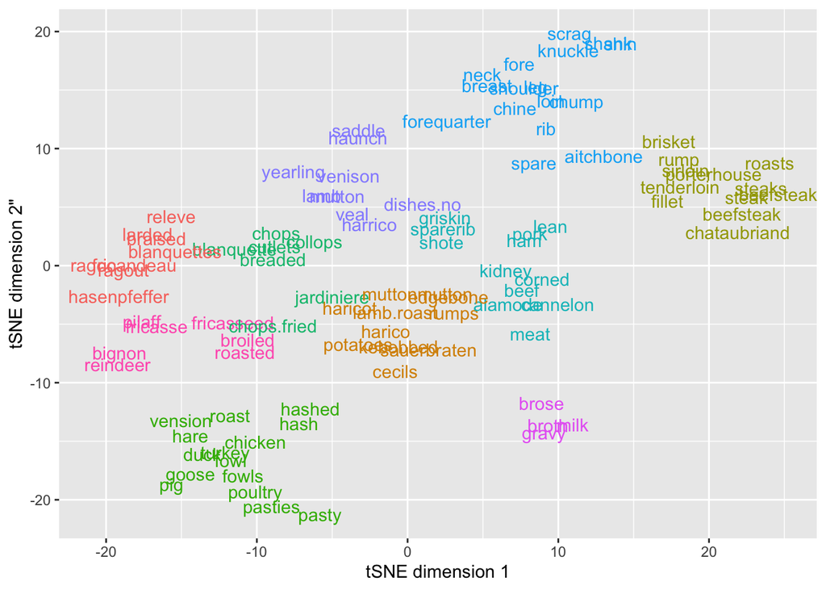

```r
embedding_vals = embedding$Y
rownames(embedding_vals) = rownames(surrounding_ingredients)

# Looking for clusters for embedding
set.seed(10)
n_centers = 10
clustering = kmeans(embedding_vals,centers=n_centers,
                    iter.max = 5)

# Setting up data for plotting
embedding_plot = tibble(x = embedding$Y[,1],
                        y = embedding$Y[,2],
                        labels = rownames(surrounding_ingredients)) %>%
  bind_cols(cluster = as.character(clustering$cluster))

# Visualizing TSNE output
ggplot(aes(x = x, y=y,label = labels, color = cluster), data = embedding_plot) +
  geom_text() +xlab('tSNE dimension 1') +ylab('tSNE dimension 2"')+theme(legend.position = 'none')
```

```r
# Topics produced by the top 3 words
sapply(sample(1:n_centers,n_centers),function(n) {
  names(clustering$cluster[clustering$cluster==n][1:10])
})
```

```
##       [,1]        [,2]       [,3]           [,4]       [,5]
##  [1,] "veal"      "breast"   "braised"      "meat"     "chicken"
##  [2,] "mutton"    "leg"      "larded"       "beef"     "roast"
##  [3,] "lamb"      "neck"     "ragout"       "pork"     "turkey"
##  [4,] "venison"   "loin"     "fricandeau"   "ham"      "fowl"
##  [5,] "saddle"    "shoulder" "releve"       "lean"     "goose"
##  [6,] "haunch"    "knuckle"  "hasenpfeffer" "kidney"   "duck"
##  [7,] "yearling"  "rib"      "ragoo"        "corned"   "poultry"
##  [8,] "harrico"   "fore"     "blanquettes"  "alamode"  "fowls"
##  [9,] "dishes.no" "spare"    NA             "cannelon" "hash"
## [10,] NA          "shin"     NA             "griskin"  "hare"
##       [,6]         [,7]    [,8]          [,9]           [,10]
##  [1,] "broiled"    "milk"  "cutlets"     "potatoes"     "steak"
##  [2,] "roasted"    "gravy" "chops"       "haricot"      "fillet"
##  [3,] "fricasseed" "broth" "breaded"     "rumps"        "steaks"
##  [4,] "reindeer"   "brose" "collops"     "muttonmutton" "tenderloin"
##  [5,] "pilaff"     NA      "blanquette"  "cecils"       "sirloin"
##  [6,] "bignon"     NA      "jardiniere"  "lamb.roast"   "rump"
##  [7,] "fricasse"   NA      "chops.fried" "sauerbraten"  "brisket"
##  [8,] NA           NA      NA            "harico"       "roasts"
##  [9,] NA           NA      NA            "kebobbed"     "beefsteak"
## [10,] NA           NA      NA            "edgebone"     "porterhouse"
```

#### 4

Now I choose three tastes to replace ingredients: salty, spicy, sweet

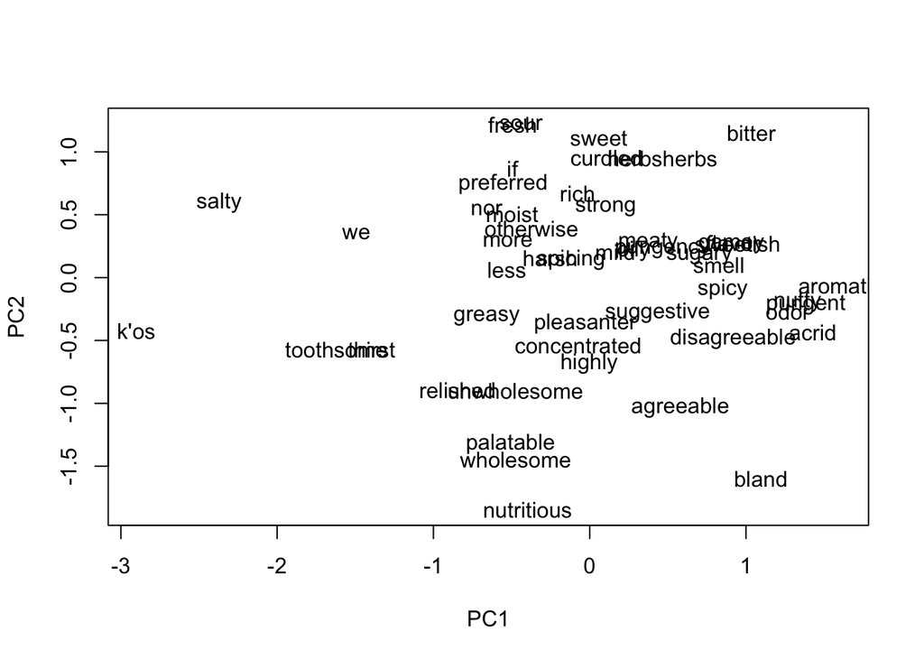

```r
taste = 'salty'
taste_2 = 'spicy'
taste_3 = 'sweet'
list_of_tastes = c(taste, taste_2, taste_3)
closest_tastes = closest_to(model,model[[list_of_tastes]], 50)$word
surrounding_tastes = model[[closest_tastes,average=F]]
plot(surrounding_tastes,method="pca")
```

Which does not really making any sense since the words are not forming clusters. We now try tSNE.

```r
embedding = Rtsne(X = surrounding_tastes, dims = 2,
                  perplexity = 4,
                  theta = 0.5,
                  eta = 10,
                  pca = TRUE, verbose = TRUE,
                  max_iter = 2000)
```

```
## Performing PCA
## Read the 50 x 50 data matrix successfully!
## OpenMP is working. 1 threads.
## Using no_dims = 2, perplexity = 4.000000, and theta = 0.500000
## Computing input similarities...
## Building tree...
## Done in 0.00 seconds (sparsity = 0.367200)!
## Learning embedding...
## Iteration 50: error is 55.341691 (50 iterations in 0.01 seconds)
## Iteration 100: error is 55.323630 (50 iterations in 0.01 seconds)
## Iteration 150: error is 55.323612 (50 iterations in 0.00 seconds)
## Iteration 200: error is 55.323552 (50 iterations in 0.00 seconds)
## Iteration 250: error is 55.323400 (50 iterations in 0.00 seconds)
## Iteration 300: error is 0.822874 (50 iterations in 0.00 seconds)
## Iteration 350: error is 0.724404 (50 iterations in 0.00 seconds)
## Iteration 400: error is 0.707822 (50 iterations in 0.00 seconds)
## Iteration 450: error is 0.704453 (50 iterations in 0.00 seconds)
## Iteration 500: error is 0.699809 (50 iterations in 0.00 seconds)
## Iteration 550: error is 0.696323 (50 iterations in 0.00 seconds)
## Iteration 600: error is 0.691617 (50 iterations in 0.00 seconds)
## Iteration 650: error is 0.693703 (50 iterations in 0.00 seconds)
## Iteration 700: error is 0.692355 (50 iterations in 0.00 seconds)
## Iteration 750: error is 0.686072 (50 iterations in 0.00 seconds)
## Iteration 800: error is 0.690801 (50 iterations in 0.00 seconds)
## Iteration 850: error is 0.692182 (50 iterations in 0.00 seconds)
## Iteration 900: error is 0.694864 (50 iterations in 0.00 seconds)
## Iteration 950: error is 0.691075 (50 iterations in 0.00 seconds)
## Iteration 1000: error is 0.693395 (50 iterations in 0.00 seconds)
## Iteration 1050: error is 0.691377 (50 iterations in 0.00 seconds)
## Iteration 1100: error is 0.687332 (50 iterations in 0.00 seconds)
## Iteration 1150: error is 0.691168 (50 iterations in 0.00 seconds)
## Iteration 1200: error is 0.692670 (50 iterations in 0.00 seconds)
## Iteration 1250: error is 0.692824 (50 iterations in 0.00 seconds)
## Iteration 1300: error is 0.691238 (50 iterations in 0.00 seconds)
## Iteration 1350: error is 0.689278 (50 iterations in 0.00 seconds)
## Iteration 1400: error is 0.689978 (50 iterations in 0.00 seconds)
## Iteration 1450: error is 0.694526 (50 iterations in 0.00 seconds)
## Iteration 1500: error is 0.693406 (50 iterations in 0.00 seconds)
## Iteration 1550: error is 0.692462 (50 iterations in 0.00 seconds)
## Iteration 1600: error is 0.692798 (50 iterations in 0.00 seconds)
## Iteration 1650: error is 0.692808 (50 iterations in 0.00 seconds)
## Iteration 1700: error is 0.692825 (50 iterations in 0.00 seconds)
## Iteration 1750: error is 0.691176 (50 iterations in 0.00 seconds)
## Iteration 1800: error is 0.692664 (50 iterations in 0.00 seconds)
## Iteration 1850: error is 0.691185 (50 iterations in 0.00 seconds)
## Iteration 1900: error is 0.689238 (50 iterations in 0.00 seconds)
## Iteration 1950: error is 0.693736 (50 iterations in 0.00 seconds)
## Iteration 2000: error is 0.689411 (50 iterations in 0.00 seconds)
## Fitting performed in 0.12 seconds.
```

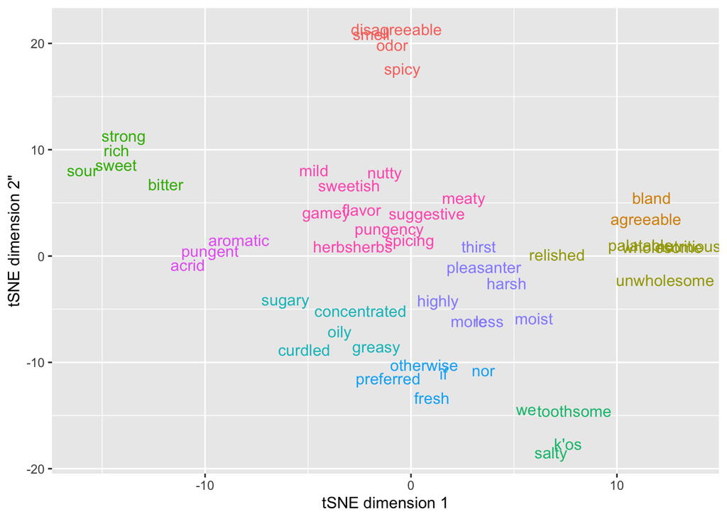

```r
embedding_vals = embedding$Y
rownames(embedding_vals) = rownames(surrounding_tastes)

# Looking for clusters for embedding
set.seed(10)
n_centers = 10
clustering = kmeans(embedding_vals,centers=n_centers,
                    iter.max = 5)

# Setting up data for plotting
embedding_plot = tibble(x = embedding$Y[,1],
                        y = embedding$Y[,2],
                        labels = rownames(surrounding_tastes)) %>%
  bind_cols(cluster = as.character(clustering$cluster))

# Visualizing TSNE output
ggplot(aes(x = x, y=y,label = labels, color = cluster), data = embedding_plot) +
  geom_text() +xlab('tSNE dimension 1') +ylab('tSNE dimension 2"')+theme(legend.position = 'none')
```

```r
# Topics produced by the top 3 words
sapply(sample(1:n_centers,n_centers),function(n) {
  names(clustering$cluster[clustering$cluster==3][1:10])
})
```

```
##       [,1]     [,2]     [,3]     [,4]     [,5]     [,6]     [,7]
##  [1,] "sweet"  "sweet"  "sweet"  "sweet"  "sweet"  "sweet"  "sweet"
##  [2,] "rich"   "rich"   "rich"   "rich"   "rich"   "rich"   "rich"
##  [3,] "strong" "strong" "strong" "strong" "strong" "strong" "strong"
##  [4,] "sour"   "sour"   "sour"   "sour"   "sour"   "sour"   "sour"
##  [5,] "bitter" "bitter" "bitter" "bitter" "bitter" "bitter" "bitter"
##  [6,] NA       NA       NA       NA       NA       NA       NA
##  [7,] NA       NA       NA       NA       NA       NA       NA
##  [8,] NA       NA       NA       NA       NA       NA       NA
##  [9,] NA       NA       NA       NA       NA       NA       NA
## [10,] NA       NA       NA       NA       NA       NA       NA
##       [,8]     [,9]     [,10]
##  [1,] "sweet"  "sweet"  "sweet"
##  [2,] "rich"   "rich"   "rich"
##  [3,] "strong" "strong" "strong"
##  [4,] "sour"   "sour"   "sour"
##  [5,] "bitter" "bitter" "bitter"
##  [6,] NA       NA       NA
##  [7,] NA       NA       NA
##  [8,] NA       NA       NA
##  [9,] NA       NA       NA
## [10,] NA       NA       NA
```

#### 5

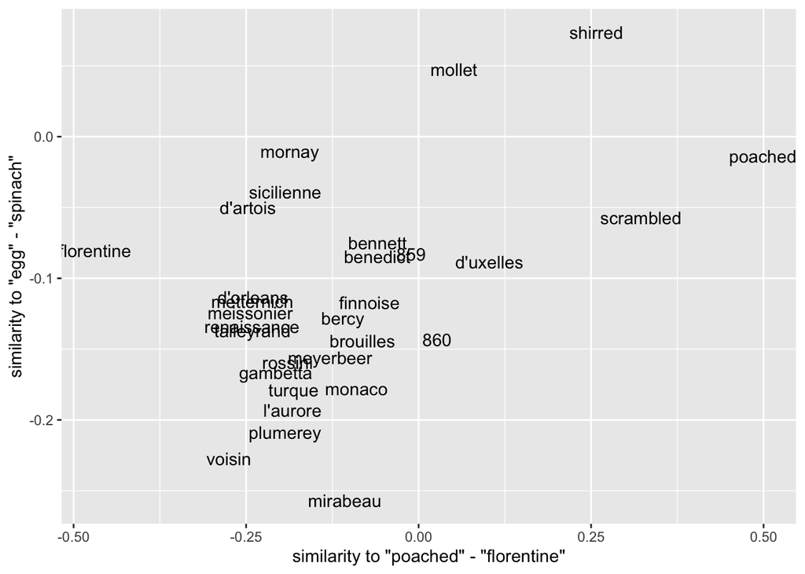

```r
top_evaluative_words = model %>%
  closest_to(~ "poached"+"florentine",n=30)
goodness = model %>%
  closest_to(~ "poached"-"florentine",n=Inf)
taste = model %>%
  closest_to(~ "egg" - "spinach", n=Inf)

top_evaluative_words %>%
  inner_join(goodness) %>%
  inner_join(taste) %>%
  ggplot() +
  geom_text(aes(x=`similarity to "poached" - "florentine"`,
                y=`similarity to "egg" - "spinach"`,
                label=word))
```

#### 6

we can see some interesting results like the words in different cuisine such as French Cuisine, Chinese Cuisine, Indian Cuisine, etc. We may see some relationships between different cuisines. There may be relationships between cuisines based on their geographic location. There may be some difficulties due to the tricky names of some cuisines.

#### 7

```r
prep_word2vec(origin="cookbooks",destination="cookbooks.txt",lowercase=T,bundle_ngrams=2)
```

```
## Beginning tokenization to text file at cookbooks.txt
```

[output not shown]

[output not shown]

[output not shown]

[output not shown]

[output not shown]

[output not shown]

[output not shown]

[output not shown]

[output not shown]

[output not shown]

[output not shown]

[output not shown]

[output not shown]

[output not shown]

[output not shown]

[output not shown]

[output not shown]

[output not shown]

[output not shown]

[output not shown]

[output not shown]

[output not shown]

[output not shown]

[output not shown]

[output not shown]

[output not shown]

[output not shown]

[output not shown]

[output not shown]

[output not shown]

[output not shown]

[output not shown]

[output not shown]

[output not shown]

[output not shown]

[output not shown]

[output not shown]

[output not shown]

[output not shown]

[output not shown]

[output not shown]

[output not shown]

[output not shown]

[output not shown]

[output not shown]

[output not shown]

[output not shown]

[output not shown]

[output not shown]

[output not shown]

[output not shown]

[output not shown]

[output not shown]

[output not shown]

[output not shown]

[output not shown]

[output not shown]

[output not shown]

[output not shown]

[output not shown]

[output not shown]

[output not shown]

[output not shown]

[output not shown]

[output not shown]

[output not shown]

[output not shown]

[output not shown]

[output not shown]

[output not shown]

[output not shown]

[output not shown]

[output not shown]

[output not shown]

[output not shown]

[output not shown]

[output not shown]

[output cut: 156 more lines]

[output not shown]

```r
# Training a Word2Vec model
model = train_word2vec("cookbooks.txt","cookbook_vectors1.bin",
                       vectors=100,threads=4,window=6,
                       min_count = 10,
                       iter=5,negative_samples=15)
```

[output not shown]

[output cut: 46 more lines]

[output not shown]

```
## Filename ends with .bin, so reading in binary format
```

```
## Reading a word2vec binary file of 25375 rows and 100 columns
```

### Question 4

#### Part 1

##### 1

```r
# read in data
data = read.csv('./Part2/kernel_regression_1.csv')
set.seed(100)
# set index
index = 990:1001
x_observed = data$x[-index]
f = data$y[-index]
x_prime = data$x
k = function(x,x_prime,l){
  d = sapply(x,FUN=function(x_in)(x_in-x_prime)^2)
  return(t(exp(-1/(2*l)*d)))
}
mu=0
mu_=0
l=10
k_f = k(x_observed, x_observed, l)
for (i in 1:dim(k_f)[1]){
  k_f[i,i] = k_f[i,i]+0.000001
  }
k_ = k(x_observed, x_prime, l)
k_star = k(x_prime, x_prime, l)
mu_ = mu_ + t(k_) %*% solve(k_f) %*% (f-mu)
sigma_ = k_star - t(k_) %*% t(solve(k_f)) %*% k_
```

##### 2

Since here we only take the kernel of log likelihood in order to maintain positive status

$$L(x_1,\ldots, x_n) = \frac{1}{(2\pi)^n|\sum|}e^{(x-\mu)^{\tau}\sum^{-1}(x-\mu)} \\
logLL \propto -log(|{\scriptstyle\sum}|) - (x - \mu)^{\tau}{\scriptstyle\sum}^{-1}(x-\mu)$$

```r
for (ll in c(1,0.1,0.01,0.00001)){
  mu=0
  mu_=0
  l=ll
  k_f = k(x_observed, x_observed, l)
  for (i in 1:dim(k_f)[1]){
    k_f[i,i] = k_f[i,i] + 0.000001
    }
  k_ = k(x_observed, x_prime, l)
  k_star = k(x_prime, x_prime, l)
  mu_ = mu_ + t(k_) %*% solve(k_f) %*% (f-mu)
  sigma_ = k_star - t(k_) %*% t(solve(k_f)) %*% k_
  sigma_test = sigma_[index, index]
  logLL = -log(det(sigma_test)) - t(data$y[index] - mu_[index]) %*% solve(sigma_test) %*% (data$y[index] - mu_[index])
  cat('theta=', ll, 'The Negative Log Likelihood is: ', -logLL,'\n')}
```

```
## theta= 1 The Negative Log Likelihood is:  NaN
```

```
## theta= 0.1 The Negative Log Likelihood is:  NaN
```

```
## theta= 0.01 The Negative Log Likelihood is:  NaN
## theta= 1e-05 The Negative Log Likelihood is:  7.944166
```

##### 3

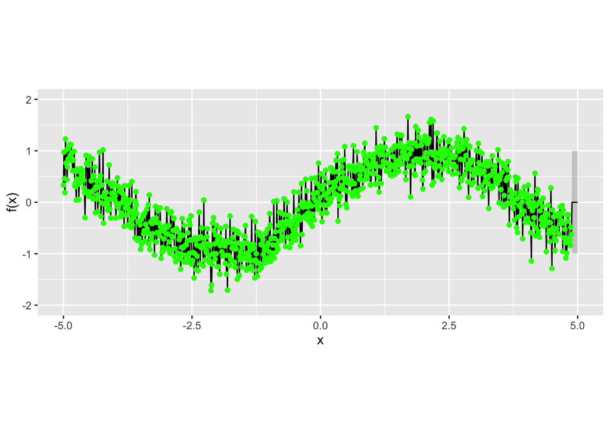

```r
gaussian_process = tibble(x = x_prime,
                          y = mu_ %>% as.vector(),
                          sd_prime = sqrt(diag(sigma_)))

# Plotting values
ggplot(aes(x = x, y = y), data = gaussian_process) +
          geom_line()+
          geom_ribbon(aes(ymin = y-sd_prime, ymax = y + sd_prime), alpha = 0.2)+
          geom_point(aes(x = x , y = y), data = tibble(x = x_observed, y = f),
          color = 'green') +
          xlim(c(-5,5)) + ylim(c(-2,2))+
          coord_fixed(ratio = 1) + ylab('f(x)')
```